# ECON 121 HW1

Wanjun Gu

1/31/2020

### Import all the libraries and data

```r
knitr::opts_chunk$set(echo = TRUE)
library(foreign)
library(readxl)
library(readstata13)
library(knitr)
library(ggplot2)
ps1_cps = read_xlsx(path = "ps1_cps.xlsx")
nlsy = read.dta13(file = "nlsy79.dta")
```

## Question 2

```r
# Data Processing
cps = as.data.frame(read_excel(path = "ps1_cps.xlsx"))
educ_yr = cbind(c("Associate's degree, occupational/vocational program",
                  "Master's degree"                                    ,
                  "Grades 7 or 8"                                      ,
                  "High school diploma or equivalent"                  ,
                  "Bachelor's degree"                                  ,
                  "Some college but no degree"                         ,
                  "Doctorate degree"                                   ,
                  "12th grade, no diploma"                             ,
                  "Associate's degree, academic program"               ,
                  "Grade 10"                                           ,
                  "Grade 11"                                           ,
                  "None or preschool"                                  ,
                  "Professional school degree"                         ,
                  "Grade 9"                                            ,
                  "Grades 1, 2, 3, or 4"                               ,
                  "Grades 5 or 6"  ),
                c(16, 18, 7.5, 12, 16, 15,
                  22, 12, 14, 10, 11, 0,
                  14, 9, 2.5, 5.5))

cps$uhrsworkt = as.numeric(cps$uhrsworkt) # Assign NA if work hour varies
assign_educ = function(x){
  return(educ_yr[which(x == educ_yr[,1]),2])
}
cps$educ = as.numeric(sapply(cps$educ, assign_educ))
cps$age = as.numeric(cps$age)
cps$sex = as.factor(cps$sex)
cps$exper = cps$age - cps$educ - 5
cps$exper2 = cps$exper^2
cps$white = as.numeric(cps$race == "White")
cps$black = as.numeric(cps$race == "Black/Negro")
cps$other = as.numeric(cps$race != "White" & cps$race != "Black/Negro")
cps$race = as.factor(cps$race)
cps$hwage = log(cps$incwage / (cps$uhrsworkt * cps$wkswork1))
cps$hwage[cps$hwage == -Inf] = 0
cps = na.omit(cps) # Get rid of all the NA values
cps = cps[cps$uhrsworkt >= 35 & cps$wkswork1 >= 50,] # Get rid of part-time
kable(head(cps)) # Display data
```

|  | age | sex | race | uhrsworkt | educ | wkswork1 | incwage | exper | exper2 | white | black | other | hwage |
| --- | --- | --- | --- | --- | --- | --- | --- | --- | --- | --- | --- | --- | --- |
| 2 | 55 | Female | White | 40 | 18 | 52 | 56000 | 32 | 1024 | 1 | 0 | 0 | 3.292984 |
| 6 | 59 | Male | White | 50 | 12 | 52 | 50000 | 42 | 1764 | 1 | 0 | 0 | 2.956512 |
| 7 | 29 | Male | White | 45 | 12 | 52 | 40000 | 12 | 144 | 1 | 0 | 0 | 2.838729 |
| 8 | 30 | Female | White | 40 | 16 | 52 | 30000 | 9 | 81 | 1 | 0 | 0 | 2.668830 |
| 9 | 40 | Male | White | 50 | 15 | 52 | 0 | 20 | 400 | 1 | 0 | 0 | 0.000000 |
| 10 | 46 | Female | White | 40 | 16 | 52 | 45000 | 25 | 625 | 1 | 0 | 0 | 3.074295 |

```r
summary(cps) # Summarize data
```

```
##       age            sex                                    race
##  Min.   :25.00   Female:22495   White                         :39825
##  1st Qu.:35.00   Male  :28784   Black/Negro                   : 5923
##  Median :43.00                  Asian only                    : 3717
##  Mean   :43.41                  American Indian/Aleut/Eskimo  :  634
##  3rd Qu.:52.00                  White-American Indian         :  342
##  Max.   :64.00                  Hawaiian/Pacific Islander only:  268
##                                 (Other)                       :  570
##    uhrsworkt          educ          wkswork1        incwage
##  Min.   : 35.0   Min.   : 0.00   Min.   :50.00   Min.   :      0
##  1st Qu.: 40.0   1st Qu.:12.00   1st Qu.:52.00   1st Qu.:  30000
##  Median : 40.0   Median :15.00   Median :52.00   Median :  48500
##  Mean   : 43.5   Mean   :14.57   Mean   :51.95   Mean   :  64346
##  3rd Qu.: 45.0   3rd Qu.:16.00   3rd Qu.:52.00   3rd Qu.:  75002
##  Max.   :170.0   Max.   :22.00   Max.   :52.00   Max.   :1609999
##
##      exper           exper2           white            black
##  Min.   :-2.00   Min.   :   0.0   Min.   :0.0000   Min.   :0.0000
##  1st Qu.:15.00   1st Qu.: 225.0   1st Qu.:1.0000   1st Qu.:0.0000
##  Median :23.00   Median : 529.0   Median :1.0000   Median :0.0000
##  Mean   :23.84   Mean   : 691.6   Mean   :0.7766   Mean   :0.1155
##  3rd Qu.:33.00   3rd Qu.:1089.0   3rd Qu.:1.0000   3rd Qu.:0.0000
##  Max.   :58.00   Max.   :3364.0   Max.   :1.0000   Max.   :1.0000
##
##      other            hwage
##  Min.   :0.0000   Min.   :-6.254
##  1st Qu.:0.0000   1st Qu.: 2.668
##  Median :0.0000   Median : 3.074
##  Mean   :0.1079   Mean   : 2.996
##  3rd Qu.:0.0000   3rd Qu.: 3.520
##  Max.   :1.0000   Max.   : 6.428
##
```

## Question 3

```r
kable(summary(lm(data = cps, hwage ~ educ + exper + exper2))$coefficient)
```

|  | Estimate | Std. Error | t value | Pr(>\|t\|) |
| --- | --- | --- | --- | --- |
| (Intercept) | 1.2566103 | 0.0292396 | 42.976331 | 0 |
| educ | 0.1028490 | 0.0014890 | 69.072179 | 0 |
| exper | 0.0181678 | 0.0016023 | 11.338398 | 0 |
| exper2 | -0.0002787 | 0.0000319 | -8.741979 | 0 |

## Question 4

```r
kable(summary(lm(data = cps, hwage ~ white + black + sex + educ + exper + exper2))$coefficient)
```

|  | Estimate | Std. Error | t value | Pr(>\|t\|) |
| --- | --- | --- | --- | --- |
| (Intercept) | 1.1530248 | 0.0320641 | 35.959958 | 0.0000000 |
| white | -0.0214552 | 0.0129493 | -1.656865 | 0.0975529 |
| black | -0.1340282 | 0.0168742 | -7.942800 | 0.0000000 |
| sexMale | 0.1875892 | 0.0080700 | 23.245342 | 0.0000000 |
| educ | 0.1057297 | 0.0014885 | 71.032201 | 0.0000000 |
| exper | 0.0169517 | 0.0015935 | 10.637776 | 0.0000000 |
| exper2 | -0.0002535 | 0.0000317 | -7.995401 | 0.0000000 |

## Question 5

```r
l = summary(lm(data = cps, hwage ~ white + black + sex + educ + exper + exper2))$coefficient
white_coef = l[2,1]
white_se = l[2,2]
male_coef = l[4,1]
male_sd = l[4,2]
se = (white_se^2+male_sd^2)^0.5
t_score = (white_coef - male_coef)/se
print(t_score)
```

```
## [1] -13.70059
```

As the result shows, t statistics is way greater than 1.96, therefore the differnece is significant.

## Question 6

```r
cps_male = cps[cps$sex == "Male",]
cps_female = cps[cps$sex == "Female",]
ml = summary(lm(data = cps_male, hwage ~ white + black + educ + exper + exper2))$coefficient
fl = summary(lm(data = cps_female, hwage ~ white + black + educ + exper + exper2))$coefficient
print("Regression results for males")
```

```
## [1] "Regression results for males"
```

```r
kable(ml)
```

|  | Estimate | Std. Error | t value | Pr(>\|t\|) |
| --- | --- | --- | --- | --- |
| (Intercept) | 1.3543112 | 0.0446224 | 30.350502 | 0.0000000 |
| white | -0.0269620 | 0.0188256 | -1.432198 | 0.1520979 |
| black | -0.1629416 | 0.0255723 | -6.371796 | 0.0000000 |
| educ | 0.1026864 | 0.0020453 | 50.206012 | 0.0000000 |
| exper | 0.0208734 | 0.0023426 | 8.910550 | 0.0000000 |
| exper2 | -0.0003353 | 0.0000461 | -7.279945 | 0.0000000 |

```r
print("Regression results for females")
```

```
## [1] "Regression results for females"
```

```r
kable(fl)
```

|  | Estimate | Std. Error | t value | Pr(>\|t\|) |
| --- | --- | --- | --- | --- |
| (Intercept) | 1.1138004 | 0.0436557 | 25.5132882 | 0.0000000 |
| white | -0.0167805 | 0.0171791 | -0.9767937 | 0.3286818 |
| black | -0.1068967 | 0.0214618 | -4.9807839 | 0.0000006 |
| educ | 0.1106325 | 0.0021375 | 51.7574453 | 0.0000000 |
| exper | 0.0122206 | 0.0020913 | 5.8434101 | 0.0000000 |
| exper2 | -0.0001500 | 0.0000422 | -3.5521645 | 0.0003829 |

Although there is no way to synthesize the standard error of the two coefficients of male and female since the samples are innately different, we can use bootstrap to determine the standard deviation of the difference between the two samples.

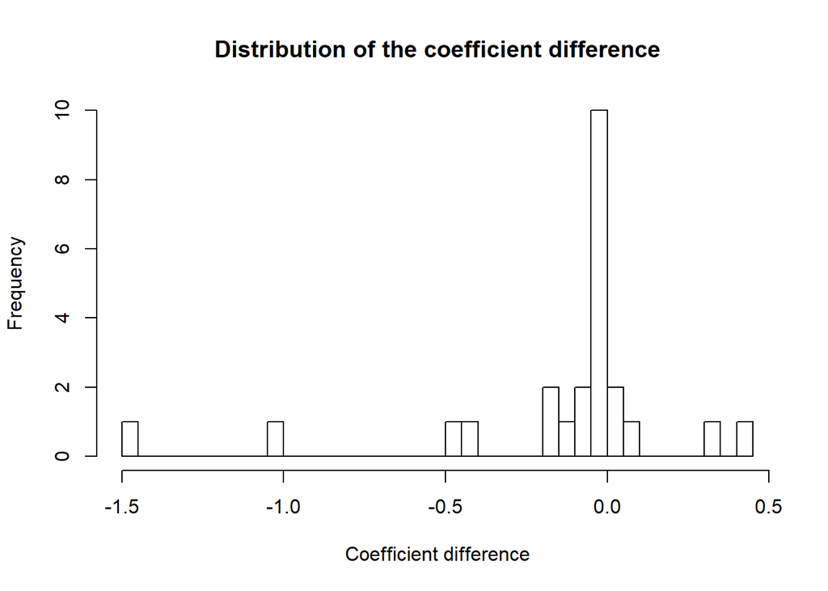

```r
# Construct a bootstrap engine
dl_list = vector()
for(i in 1:1000){
  cps_male_sample = cps_male[sample(1:dim(cps_male)[1], 1000, replace = TRUE),]
  cps_female_sample = cps_male[sample(1:dim(cps_female)[1], 1000, replace = TRUE),]
  ml = summary(lm(data = cps_male_sample, hwage ~ white + black + educ + exper + exper2))$coefficient
  fl = summary(lm(data = cps_female_sample, hwage ~ white + black + educ + exper + exper2))$coefficient
  dl = ml - fl
  dl_list = c(dl_list, dl)
}
hist(dl, breaks = 50, main = "Distribution of the coefficient difference",
     xlab = "Coefficient difference")
```

```r
print(paste0("Mean Difference: ", mean(dl)))
```

```
## [1] "Mean Difference: -0.133405598431262"
```

```r
print(paste0("Difference SE: ", sd(dl)))
```

```
## [1] "Difference SE: 0.395711981006444"
```

As shown in the bootstap result, the difference is not sigificant. Therefore, the education returns in male and female seperately are not statistically significant.

## Question 7

```r
cps$male = as.numeric(as.factor(cps$sex)) - 1
interact_l = summary(lm(data = cps, hwage ~ white + black + educ + exper + exper2 + I(male*educ)))$coefficient
kable(interact_l)
```

|  | Estimate | Std. Error | t value | Pr(>\|t\|) |
| --- | --- | --- | --- | --- |
| (Intercept) | 1.2723547 | 0.0315085 | 40.381267 | 0.0000000 |
| white | -0.0202005 | 0.0129536 | -1.559453 | 0.1188954 |
| black | -0.1343747 | 0.0168809 | -7.960163 | 0.0000000 |
| educ | 0.0980912 | 0.0014953 | 65.598967 | 0.0000000 |
| exper | 0.0169183 | 0.0015942 | 10.612222 | 0.0000000 |
| exper2 | -0.0002541 | 0.0000317 | -8.011397 | 0.0000000 |
| I(male * educ) | 0.0121233 | 0.0005409 | 22.414143 | 0.0000000 |

## Question 8

```r
# Display data
kable(head(nlsy[,1:8]))
```

| age79 | foreign | urban14 | mag14 | news14 | lib14 | educ_mom | educ_dad |
| --- | --- | --- | --- | --- | --- | --- | --- |
| 20 | 1 | 1 | 0 | 1 | 1 | 8 | 8 |
| 20 | 1 | 1 | 1 | 1 | 1 | 5 | 8 |
| 17 | 0 | 1 | 1 | 1 | 1 | 10 | 12 |
| 16 | 0 | 1 | 1 | 1 | 0 | 11 | 12 |
| 19 | 0 | 1 | 1 | 1 | 1 | 12 | 12 |
| 18 | 0 | 1 | 0 | 1 | 1 | 12 | 12 |

```r
# Unweighted summary
black = na.omit(nlsy$black)
hisp = na.omit(nlsy$hisp)

black_mean = sum(black, na.rm = TRUE)/length(black)
hisp_mean = sum(hisp, na.rm = TRUE)/length(hisp)

black_sd = ((black_mean * (1-black_mean))/length(black))^0.5
hisp_sd = ((hisp_mean * (1-hisp_mean))/length(hisp))^0.5


#Weighted summary
black_mean_weight = sum(black*nlsy$perweight, na.rm = TRUE)/sum(nlsy$perweight)
hisp_mean_weight = sum(hisp*nlsy$perweight, na.rm = TRUE)/sum(nlsy$perweight)

black_sd_weight = ((black_mean_weight * (1-black_mean_weight))/length(black))^0.5
hisp_sd_weight = ((hisp_mean_weight * (1-hisp_mean_weight))/length(hisp))^0.5

Q8 = data.frame(
  black_mean = sum(black, na.rm = TRUE)/length(black),
  hisp_mean = sum(hisp, na.rm = TRUE)/length(hisp),

  black_sd = ((black_mean * (1-black_mean))/length(black))^0.5,
  hisp_sd = ((hisp_mean * (1-hisp_mean))/length(hisp))^0.5,


  #Weighted summary
  black_mean_weight = sum(black*nlsy$perweight, na.rm = TRUE)/sum(nlsy$perweight),
  hisp_mean_weight = sum(hisp*nlsy$perweight, na.rm = TRUE)/sum(nlsy$perweight),

  black_sd_weight = ((black_mean_weight * (1-black_mean_weight))/length(black))^0.5,
  hisp_sd_weight = ((hisp_mean_weight * (1-hisp_mean_weight))/length(hisp))^0.5)

kable(Q8)
```

| black_mean | hisp_mean | black_sd | hisp_sd | black_mean_weight | hisp_mean_weight | black_sd_weight | hisp_sd_weight |
| --- | --- | --- | --- | --- | --- | --- | --- |
| 0.2501971 | 0.1578118 | 0.0038455 | 0.0032368 | 0.1418509 | 0.0654364 | 0.0030977 | 0.0021956 |

The weighted summary better discribes the population ratio becuase in the unweighted sampings, due to the fact that black and hispanics are Ethnic minorities, they are upsampled and therefore over-represented Considering weight can eliminate the differences.

## Question 9

```r
hour_wage = log(nlsy$laborinc07/nlsy$hours07)
hour_wage[hour_wage == -Inf] = 0

experience = nlsy$age79 + 28 - nlsy$educ - 5

nlsy_plus = cbind(nlsy, experience, hour_wage)
nlsy_plus = subset(nlsy_plus, hours07 > 1750)
nlsy_plus = na.omit(nlsy_plus)

rm(experience, hour_wage)

# For black
print("Unweighted summary for the black")
```

```
## [1] "Unweighted summary for the black"
```

```r
kable(summary(lm(data = nlsy_plus, hour_wage ~ educ +
                   I(experience^2) +
                   experience + black + male))$coefficient)
```

|  | Estimate | Std. Error | t value | Pr(>\|t\|) |
| --- | --- | --- | --- | --- |
| (Intercept) | 2.7016775 | 0.6577952 | 4.107171 | 0.0000409 |
| educ | 0.1255954 | 0.0084000 | 14.951855 | 0.0000000 |
| I(experience^2) | 0.0026465 | 0.0008244 | 3.210304 | 0.0013369 |
| experience | -0.1342427 | 0.0448467 | -2.993366 | 0.0027769 |
| black | -0.2188915 | 0.0317476 | -6.894745 | 0.0000000 |
| male | 0.2645347 | 0.0278221 | 9.508090 | 0.0000000 |

```r
print("Weighted summary for the black")
```

```
## [1] "Weighted summary for the black"
```

```r
kable(summary(lm(data = nlsy_plus, hour_wage ~ educ +
                   I(experience^2) +
                   experience + black + male, weights = perweight))$coefficient)
```

|  | Estimate | Std. Error | t value | Pr(>\|t\|) |
| --- | --- | --- | --- | --- |
| (Intercept) | 2.3082053 | 0.6918313 | 3.336370 | 0.0008569 |
| educ | 0.1304702 | 0.0082055 | 15.900332 | 0.0000000 |
| I(experience^2) | 0.0023259 | 0.0008866 | 2.623437 | 0.0087394 |
| experience | -0.1136084 | 0.0478590 | -2.373817 | 0.0176545 |
| black | -0.2308859 | 0.0447666 | -5.157550 | 0.0000003 |
| male | 0.3060472 | 0.0279673 | 10.943041 | 0.0000000 |

```r
# For Hispanic
print("Unweighted summary for the hispanic")
```

```
## [1] "Unweighted summary for the hispanic"
```

```r
kable(summary(lm(data = nlsy_plus, hour_wage ~ educ +
                   I(experience^2) +
                   experience + hisp + male))$coefficient)
```

|  | Estimate | Std. Error | t value | Pr(>\|t\|) |
| --- | --- | --- | --- | --- |
| (Intercept) | 2.8177221 | 0.6630552 | 4.2496040 | 0.0000219 |
| educ | 0.1273055 | 0.0084832 | 15.0067059 | 0.0000000 |
| I(experience^2) | 0.0029466 | 0.0008290 | 3.5543455 | 0.0003835 |
| experience | -0.1501018 | 0.0451024 | -3.3280229 | 0.0008829 |
| hisp | 0.0238112 | 0.0375895 | 0.6334539 | 0.5264752 |
| male | 0.2765659 | 0.0279506 | 9.8948241 | 0.0000000 |

```r
print("Weighted summary for the hispanic")
```

```
## [1] "Weighted summary for the hispanic"
```

```r
kable(summary(lm(data = nlsy_plus, hour_wage ~ educ +
                   I(experience^2) +
                   experience + hisp + male, weights = perweight))$coefficient)
```

|  | Estimate | Std. Error | t value | Pr(>\|t\|) |
| --- | --- | --- | --- | --- |
| (Intercept) | 2.3432575 | 0.6946602 | 3.3732429 | 0.0007503 |
| educ | 0.1317033 | 0.0082426 | 15.9783250 | 0.0000000 |
| I(experience^2) | 0.0024453 | 0.0008896 | 2.7487750 | 0.0060100 |
| experience | -0.1198860 | 0.0480238 | -2.4963905 | 0.0125883 |
| hisp | 0.0041861 | 0.0625679 | 0.0669041 | 0.9466615 |
| male | 0.3130156 | 0.0280345 | 11.1653726 | 0.0000000 |

The usage of sampling weight can slightly change the coefficient and increase the standard error of the statistics. However, Weighted regression is preferred because it takes consideration of the Over sampling of minority populations such as hispanic or black. Therefore, I prefer the weighted regression.

## Question 10

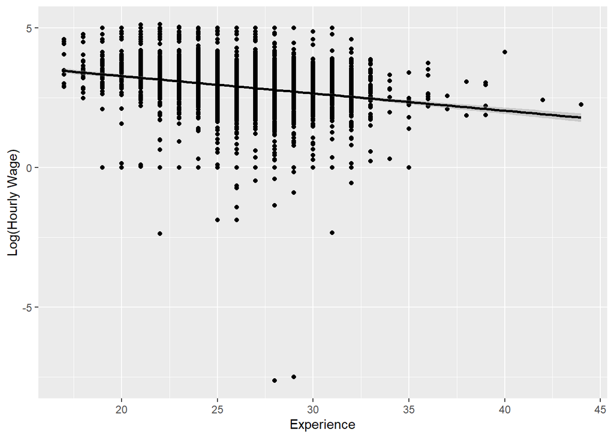

```r
ggplot(data = nlsy_plus, aes(x = experience, y = hour_wage)) +
  geom_point() +
  geom_smooth(method = "lm", color = "black") +
  xlab("Experience") +
  ylab("Log(Hourly Wage)")
```

## Question 11

I think $\beta_1$ does not represent the causal effect of education. This is because although the correlation between education and hour wage is found to be significant. There is no evidence indicating causality. In fact, there may be many other variables correlated with both education and wage that are ommited in this regression For instance, family income is traditionally believed to be correlated with education because richer households tend to afford more education. Wealth status is also related to wage given that difference in parents’ income may suggest difference in access to resources. Therefore, we cannot prove that the regression is not subjective to ommited variable bias and we cannot determin causal correlation.

## Question 12

|  | Estimate | Std. Error | t value | Pr(>\|t\|) |
| --- | --- | --- | --- | --- |
| (Intercept) | 2.7527504 | 0.6590189 | 4.177043 | 0.0000302 |
| educ | 0.1245644 | 0.0084399 | 14.758978 | 0.0000000 |
| I(experience^2) | 0.0026805 | 0.0008248 | 3.249907 | 0.0011644 |
| experience | -0.1361035 | 0.0448682 | -3.033405 | 0.0024344 |
| black | -0.2298632 | 0.0329400 | -6.978241 | 0.0000000 |
| hisp | -0.0483787 | 0.0387629 | -1.248066 | 0.2120835 |
| male | 0.2630655 | 0.0278449 | 9.447518 | 0.0000000 |

|  | Estimate | Std. Error | t value | Pr(>\|t\|) |
| --- | --- | --- | --- | --- |
| (Intercept) | 3.7232917 | 0.6551837 | 5.682821 | 0.0000000 |
| educ | 0.0662963 | 0.0098559 | 6.726588 | 0.0000000 |
| I(experience^2) | 0.0030033 | 0.0008127 | 3.695461 | 0.0002226 |
| experience | -0.1672974 | 0.0442697 | -3.779045 | 0.0001598 |
| black | -0.0424899 | 0.0370793 | -1.145918 | 0.2519008 |
| hisp | 0.0709117 | 0.0403266 | 1.758437 | 0.0787533 |
| male | 0.2288108 | 0.0275976 | 8.290959 | 0.0000000 |
| urban14 | 0.0660547 | 0.0331545 | 1.992329 | 0.0464061 |
| afqt81 | 0.0073370 | 0.0006767 | 10.843085 | 0.0000000 |

I think living at urban places at the age of 14 and AFQT should be included in the regression. As the statistics shows, the coefficients of both Urban14 and AFQT81 are significant. As an explaination, the AFQT score is a good indicator of one’s cognitive ability and should be correlated with earning, since we expect smart people to earn more. Also living in urban environment at a early age can be significant to access to resource and education quality. Therefore, I expect these two factors to be added to the regression.

## Question 13

In a natural experiment or survey setting, it’s hard for OLS to indicate causal relationship because non of the conditons are randomly assigned. Therefore, it is hard to include/control all the variables that are potentially correlated with the error term. The coefficients are thus only good for passvie prediction but not causation.